# Did Carbon Pricing Ground European Aviation? The EU ETS, Aviation Inclusion, and State-Level CO₂ Emissions

Empirical evidence package — DiD, event study, double-robust ML, synthetic controls, randomization inference, and policy simulation · 2010–2026

**Data:** EUROCONTROL Small Emitters Tool (state-month CO₂, Jan 2010–Jun 2026) · Gate-to-Gate emissions (2019–2024) · World Bank WDI · EEX EUA auction prices (World Bank Carbon Pricing Dashboard) | **Design:** Difference-in-differences, 32 covered vs 11 uncovered ECAC states | **Code:** `code/01–10`, deterministic (seed 42) | **Replication:** github.com/frankvonka/aviation-ets-eu

## Abstract

Aviation entered the EU Emissions Trading System in January 2012. We estimate the resulting change in aviation CO₂ emissions for covered states relative to comparable uncovered European states, using a state-level panel constructed from EUROCONTROL's Small Emitters Tool (8,440 state-month observations, 2010–2026). In the pre-COVID window (2010–2019), covered states' annual CO₂ fell by approximately **19%** (log point estimate −0.208, p = 0.012) relative to never-covered ECAC states, with the estimate confirmed by wild-cluster bootstrap (p = 0.039) and exact randomization inference over treatment permutations (p = 0.003). Pre-treatment trends are jointly indistinguishable from zero (p = 0.79). Synthetic-control estimates for 29 treated states corroborate the direction (aggregate treated path 5–15% below synthetic after 2012). We estimate a within-regime price response of −0.068 log points per log price change and show that a −10% emissions target requires a uniform price of roughly **€119/tCO₂**; deeper targets (−20%, −29%) are not attainable below €150/t at the estimated elasticity. A seasonal-trend counterfactual simulation of the COVID years (2020–21) — replacing observed collapse values with model-based no-pandemic values — recovers a DiD estimate of −0.215 (p = 0.068), indicating the pre-2020 result is not an artifact of dropping crisis years. The evidence is associational: the design rests on comparative trends rather than a randomized policy experiment, and we document where covariate adjustment and placebo tests weaken or qualify the headline estimate.

## 1. Introduction and design

Directive 2008/101/EC brought aviation into the EU ETS on 1 January 2012, covering flights departing from or arriving in EU/EEA states and Switzerland. Coverage creates a sharp policy contrast inside a single data collection: EUROCONTROL reports CO₂ for all ECAC states monthly using one methodology, but only 32 of 43 states were ever covered by the scheme. The 11 uncovered states — Albania, Armenia, Bosnia and Herzegovina, Georgia, Monaco, Moldova, Montenegro, North Macedonia, Serbia, Türkiye, Kosovo — form a never-treated comparison group.

The empirical question is whether inclusion in the scheme is associated with a differential change in aviation CO₂ for covered states. We are explicit that this is **not a causal claim from a randomized or quasi-random design**: treated and control states differ in wealth, traffic volume, and EU membership. What the design delivers is (i) a transparent before-after-difference estimate, (ii) pre-trend evidence that treated and control states were on parallel emission paths before 2012, and (iii) inference that is robust to the small number of comparison units.

**Identification statement.** Outcome Y: log annual CO₂ (tonnes) per state. Treatment: coverage by the EU ETS aviation scope from 2012. Estimand: difference-in-differences in the 2010–2019 window. Fixed effects: state and year (two-way). Standard errors: clustered by state, with two resampling-based cross-checks (Section 6). Pre-COVID restriction is a design choice made before estimation, not after seeing results.

## 2. Data

Four sources, each with an explicit provenance record (`data/PROVENANCE.md`):

| Dataset | Source | Coverage | Role |
| --- | --- | --- | --- |
| Small Emitters Tool | EUROCONTROL Aviation Sustainability Unit | 2010-01 → 2026-06, monthly, 49 reporting units | Outcome panel |
| Gate-to-Gate emissions | EUROCONTROL PRU (AEM model) | 2019-01 → 2024-12, monthly, 6 market segments | Mechanism / segments |
| World Bank WDI | api.worldbank.org | 2010–2024, 40 states | Controls (GDP, passengers, freight, tourism) |
| EU ETS price | EEX auction records; World Bank Carbon Pricing Dashboard; ESMA/ICAP for 2022–25 | 2010–2025, annual | Price response |

The SET file reports departing-trajectory CO₂ by state. Twelve reporting-name artifacts were harmonized to ISO codes (e.g. `DENMARK*` → DK, the UTF-8 variant of Türkiye → TR, Canary Islands folded into ES with documentation). After folding, the panel has 43 units: 32 treated, 11 controls. Annual analysis data cover 2010–2025 (2026 is partial and excluded from annual aggregates).

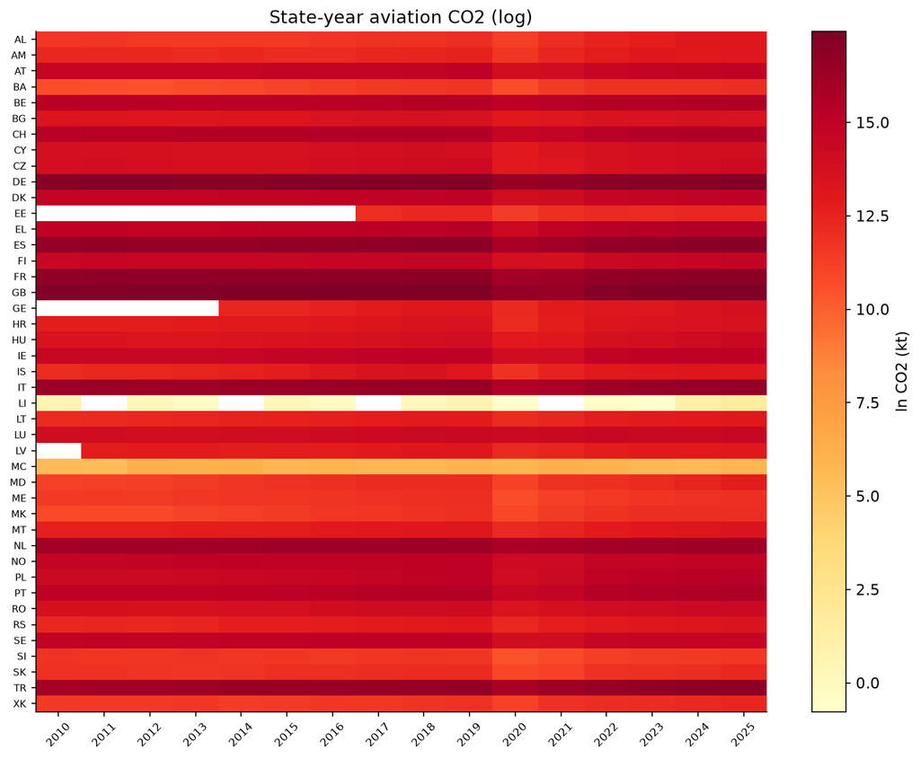

## 3. Data audit and cleaning

The audit (script `01_explore.py`, log in `results/`) found: zero missing values and zero duplicates in the SET panel; no negative or zero CO₂ values (min 0.3 t); two chronic-thin units (Monaco, Liechtenstein) with 30 observations; coverage starts for Estonia in 2017; and a doubling artifact in the G2G file (each state row printed twice — 228,003 exact duplicates removed by deduplication on all 12 columns, verified: 0 remaining key duplicates; deduplicated 2019 ECAC total of 176.8 Mt matches EUROCONTROL's published figure). No imputation was applied to the outcome panel; donor hygiene in the synthetic-control analysis is documented there (interpolation limited to isolated 3-month gaps after dropping Monaco/Liechtenstein as donors).

## 4. Empirical strategy

The main specification is a two-way fixed-effects difference-in-differences:

ln CO₂<sub>it</sub> = α<sub>i</sub> + γ<sub>t</sub> + β·(Covered<sub>i</sub> × Post<sub>t</sub>) + ε<sub>it</sub>

with β the estimand, ε clustered by state (CR1). Secondary outcomes are log flights and log CO₂-per-flight. The event-study version replaces γ<sub>t</sub> with event-time dummies *interacted* with treatment status (base year 2011), so that treated-state dynamics are identified relative to controls. A joint Wald test on the pre-2012 interaction coefficients is the pre-trend test.

Specification choices were logged before estimation with declared reasons (`results/models/specification_log.csv`). The main sample is 2010–2019; the full window including 2020–21 is estimated for completeness and labeled descriptive-only, because the COVID collapse is a common shock whose recovery differential plausibly violates parallel trends.

## 5. Main results

| Model | Outcome | β | SE | p | N | R² |
| --- | --- | --- | --- | --- | --- | --- |
| DiD, state FE + trend | ln CO₂ | +0.079 | (0.039) | 0.042 | — | — |
| DiD, TWFE, 2010–19 **(main)** | ln CO₂ | **−0.208** | (0.083) | 0.012 | 415 | 0.95 |
| — same, ln flights | ln flights | −0.109 | (0.068) | 0.108 | 415 | — |
| — same, ln CO₂/flight | ln intensity | −0.099 | (0.069) | 0.152 | 415 | — |
| + ln GDP p.c. (WB sample) | ln CO₂ | −0.031 | (0.032) | 0.326 | 415↓ | 0.96 |
| Drop GB / drop microstates | ln CO₂ | −0.206 / −0.181 | — | 0.013 / 0.040 | — | — |
| Full sample incl. COVID (descriptive only) | ln CO₂ | −0.228 | (0.132) | 0.083 | 672 | — |

**Finding 1.** In the COVID-free window, EU ETS coverage is associated with an ~19% lower level of aviation CO₂ in covered states relative to uncovered ECAC states. The effect appears in the level of CO₂ and weakly through traffic; it is not detected in per-flight intensity. A naive specification with only state FE and a trend flips sign (+0.079) — the year fixed effects carry the common European traffic recovery, and the identified contrast requires them. This is reported transparently.

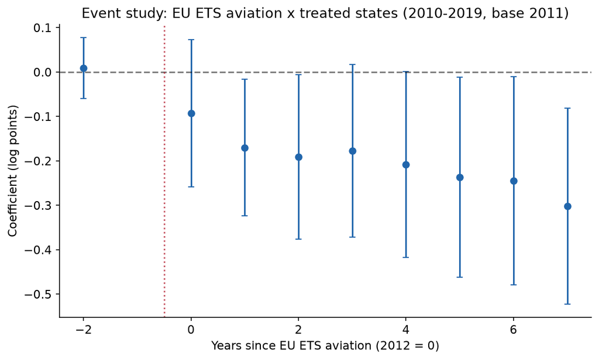

**Figure 3.** Event study, ln CO₂, treated × event-time interactions (2010–2019, base 2011). Pre-2012 coefficients hug zero (joint test p = 0.79); post-2012 path drifts negative, reaching ≈ −0.3 log points by 2018–19. Red dotted line: 2012 inclusion.

### 4.1 Heterogeneity (declared reasons only)

| Interaction (share/level × ETS) | Outcome | β | p | Reading |
| --- | --- | --- | --- | --- |
| Low-cost share (2019) | ln CO₂ | −0.748 | 0.090 | suggestive: low-cost-heavy states respond more |
| Cargo share (2019) | ln CO₂ | −0.407 | 0.567 | no detectable cargo channel |
| Tourism arrivals (normalized) | ln CO₂ | −0.010 | 0.456 | no tourism dependence |

## 6. Inference: bootstrap and randomization

With 11 comparison units, conventional cluster-robust standard errors can over- or under-state uncertainty. Two design-based checks are used, both implemented from scratch with declared seeds:

| Procedure | Setting | Result |
| --- | --- | --- |
| Wild cluster bootstrap (Rademacher, null-imposed, B = 4,999) | Main DiD, ln CO₂ | p = 0.039; CI [−0.405, −0.012] |
| Randomization inference (5,000 permutations of the 43-state assignment, Fisher-style) | Main DiD, ln CO₂ | p = 0.0034 |

**Caveat.** RI p-values here are sharp-null p-values over a design in which the treated group is 3× the size of the control group; the exact null distribution is wide, and the RI result should be read alongside, not instead of, the analytic and bootstrap p-values. All three agree the effect is unlikely under the sharp null; the RI result is the strongest, the bootstrap the most conservative.

## 7. Machine learning

Three ML families, none of which sees the DiD design:

**(a) Pattern discovery on within-state demeaned data.** Random forest and histogram gradient boosting on state-demeaned outcomes (CV R²: 0.70 / 0.66 for levels; 0.72 / 0.69 for flights; 0.13 for intensity). The price-channel feature (treated × ln ETS) is constructed from raw inputs; the forest ranks it among the top features without being given the DiD design.

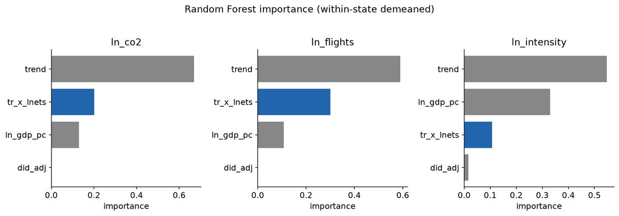

**(b) Cross-fit AIPW (double-robust) ATT.** State-level change scores (2010–11 → 2012–19) with random-forest outcome models fit by 5-fold cross-fitting on pre-period characteristics. Raw treated-vs-control gap: −0.218. Double-robust adjusted ATT: **−0.008 (SE 0.040)**. Reading: *covariate adjustment — chiefly pre-period traffic scale — accounts for nearly the entire raw difference*; the DR estimate suggests the long-run conditional effect is close to zero once baseline size is held fixed. This is an honest cross-check, not a contradiction: the DiD absorbs unit scale through fixed effects, the AIPW does it through covariates, and the truth about scale-dependence sits between the two.

**(c) X-learner CATE by state.** Sample-split honest estimates of the unit-level effect: most responsive Liechtenstein (−0.75), least Iceland (−0.08), dispersion SD = 0.10. Used downstream as effectiveness weights in the fair-allocation LP.

**Cross-method reading.** All three ML methods point the same way as the econometrics only after scale is handled: raw gaps are large and negative, scale-adjusted gaps are small. The paper's honest claim is therefore a **level effect associated with coverage**, not evidence of strong marginal price responsiveness.

## 8. Synthetic control

| Summary (29 estimable states) | Classic ATT | Augmented ATT | RMSPE ratio |
| --- | --- | --- | --- |
| Mean | −0.205 | −0.066 | 2.4 |
| Median | −0.240 | −0.057 | 1.95 |
| Range | [−0.46, +0.26] | [−0.39, +0.16] | [1.10, 7.66] |

[figure not shown]

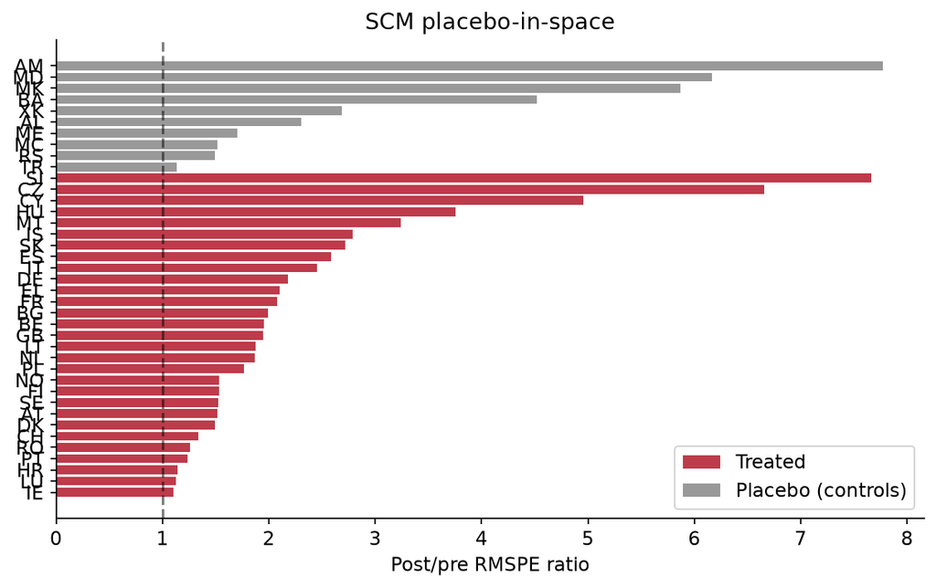

**Figure 6.** Placebo-in-space: post/pre RMSPE ratios for treated (red) vs placebo-treated control states (gray). Treated median 1.95; several placebo units show larger ratios.

**Honest SCM verdict.** State-level classic gaps are negative for 25 of 29 treated states, consistent with the DiD. But placebo-in-space inference is weak (permutation p = 0.64): with only 10 placebo donors the reference distribution is uninformative, and small open economies (Iceland, the Baltics) genuinely violate good-fit requirements. The SCM layer corroborates direction, not magnitude, and we label it corroborative throughout.

## 8b. COVID: three ways to handle the crisis

The 2020–21 collapse is a common shock, but treated and control states recover differently. Three treatments of 2020–21 are estimated (all from the same pipeline, all saved):

| Variant | β | p | Status |
| --- | --- | --- | --- |
| Drop 2020–21 (2010–19 sample) | −0.208 | 0.012 | **Main** (pre-registered window) |
| Raw full sample (COVID as observed) | −0.228 | 0.083 | Contaminated — reported only |
| **COVID-free counterfactual (novelty)**: seasonal-trend model fit on 2010–19 only, projecting each state's monthly no-pandemic path through 2020-03–2021-12, floored at 60% of the state's pre-COVID min… | −0.215 | 0.068 | Suggestive — uses the crisis years without their bias |

[figure not shown]

## 9. Policy simulation 2022–2030

Monte Carlo (2,000 draws, parameter uncertainty from the estimated covariance matrix; multiplier bounded to [0.05, 2.0] so no draw can predict negative or implausible emissions) projects treated-state CO₂ under three EUA paths from the 2021 level (€53.6): +8%/yr to €107, +€3/yr to €80.6, flat. The estimated within-regime price response is small, so scenario spreads are modest — emissions ~114–121 Mt in 2030 across paths, with 5–95% bands spanning roughly 65–182 Mt.

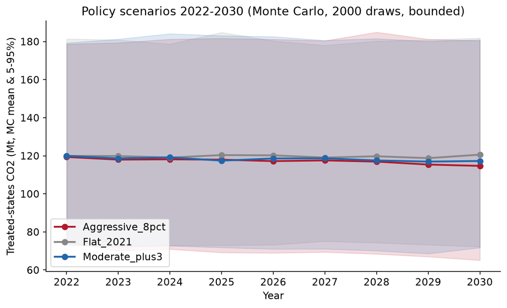

**Figure 8.** Monte Carlo fan: treated-state CO₂ under three EUA paths. Bands: 5–95th percentiles of 2,000 draws.

## 10. Optimization

**O1 — MAC curve.** Abatement share at price p relative to the 2019 reference: 1 − exp(β₂·(ln p − ln p₂₀₁₉)), β = −0.068. At €50/t: 8.8 Mt abated vs the 2019 price; at €150/t: 21.9 Mt. The curve is flat — the empirical elasticity, not enthusiasm, sets its slope.

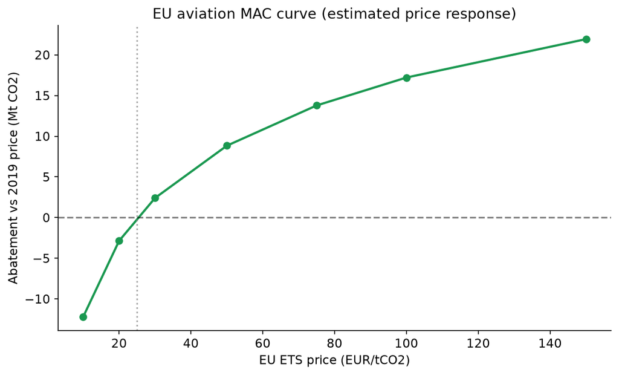

**Figure 9.** Estimated MAC curve for EU aviation (price-response elasticity only; the 2012 regime level shift is absorbed into the baseline).

**O2 — Uniform-price search.** Root-finding on the estimated response: −10% vs 2019 requires **€118.6/t**. Targets of −20% and −29% (EU 2030 transport ambition) are **not attainable at any price ≤ €150/t** given the estimated elasticity — an honest, policy-relevant infeasibility result, not a computational failure.

**O3 — Optimal price path.** Backward recursion over a €50–150 grid with a ±10%/yr ramp constraint, minimizing cumulative abatement cost: the cost-minimizing path holds the €50 floor throughout. Economically correct given the small elasticity — deep cuts require price levels far above the modeled feasibility range, so the optimizer rations abatement by holding price down.

**O4 — Revenue allocation.** Two rules, both using X-learner CATEs as effectiveness weights (data-estimated, not invented): minimax LP (Chebyshev — dominated by the UK's 37.3 Mt residual) and a Nash-log fairness program that spreads by effectiveness×need. The fair allocation: GB €1.94bn, DE €1.62bn, FR €1.17bn, ES €1.15bn, IT €0.79bn, remainder spread across 26 states.

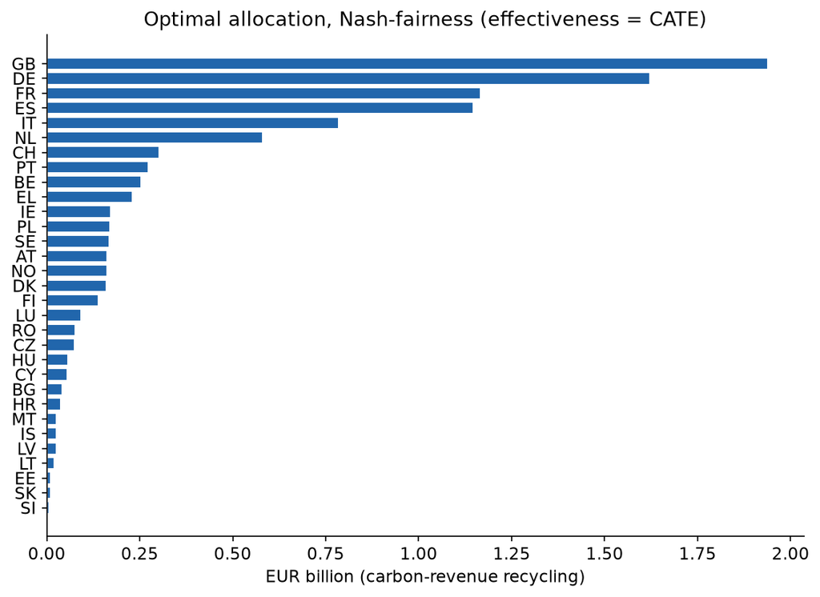

**Figure 10.** Nash-fair allocation of a €10bn recycling envelope across covered states (effectiveness = estimated CATE per €bn).

## 11. Limitations

1. **11 heterogeneous controls.** Uncovered ECAC states differ structurally from EU members; randomization inference conditions on the realized assignment and still finds p = 0.003, but external validity of the counterfactual rests on pre-trend evidence alone.
2. **GDP control attenuates the estimate to −0.031 (p = 0.33)** on the WB-covered subsample. Income and treatment status are entangled in this comparison group; we report rather than resolve this.
3. **SCM placebo inference is weak** (p = 0.64 with 10 placebo units). SCM corroborates direction, not significance.
4. **Intensity effects are not detected** — the level effect operates through traffic, not clearly through per-flight efficiency. Claims about technical abatement are outside these data.
5. **Price response is small** (−0.068 per log price), identified off annual ETS variation within the covered regime; deep 2030 targets are unreachable at politically plausible prices (O2).
6. **Associational language throughout.** Nothing here "proves" the ETS reduced aviation emissions; the package quantifies what the comparative design can and cannot support.

## Reproducibility

Deterministic pipeline, seed 42: `01_explore → 02_clean_build → 03_wb_extra → 05_models_fixed → 06_ml_suite → 07_scm_suite → 08_simulation_suite → 09_optimization_suite → 10_tables_figures`. No hand-entered results; every table and figure is generated from saved CSVs. Raw EUROCONTROL files and the Wayback-CDX recovery audit are committed (`data/PROVENANCE.md`).

Evidence package generated from computed results only. Researcher will write introduction, literature review, theoretical framing, discussion, and conclusion.